# HSC Survey Results

# German Bank Survey # 3 Results from 03/09/2023

## Survey Details

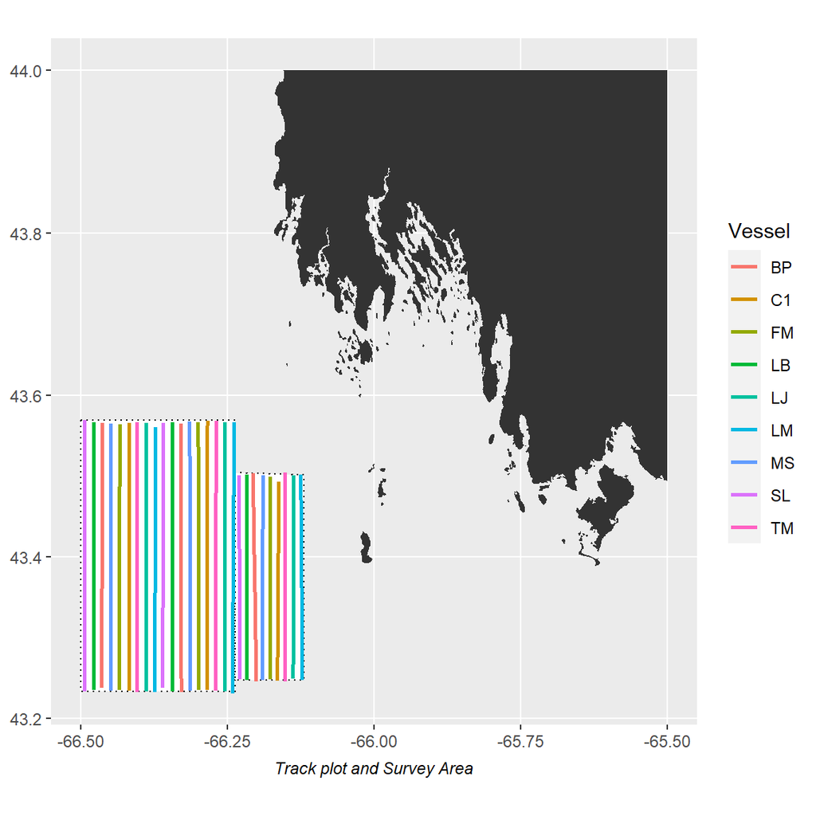

9 commercial purse seiners conducted this fishing survey on 03/09/2023 starting at 20:30:00.

All vessels ran two transects in the German Bank box and one transect in the Seal Island Box.

There was a plankton tow and replicate conducted and CTD cast by Lady Melissa.

A total of 1,248 tags were applied during the survey over 5 event(s) from 2023-09-03 to 2023-09-04 from 4 vessel(s).

Samples were obtained for target strength estimation.

### Acoustic Equipment

Each vessel was equipped with a Simrad ES38-18/200-18C combi (2-in-1) transducer prior to the survey that contains a 38kHz split beam and 200 kHz single beam transducer. Data was logged to the computer hard-drive for post-processing. All participating boats were calibrated on 38kHz before the survey.

## Survey Results

### Main Results

The results are subject to change as DFO will re-evaluate data editing, area estimation and apply a target strength.

**Preliminary biomass prediction for German Bank using standardized parallel transects is 9,959mt, and with turnover applied 8,901mt. The preliminary biomass estimate for Seal Island is 2,063mt.**

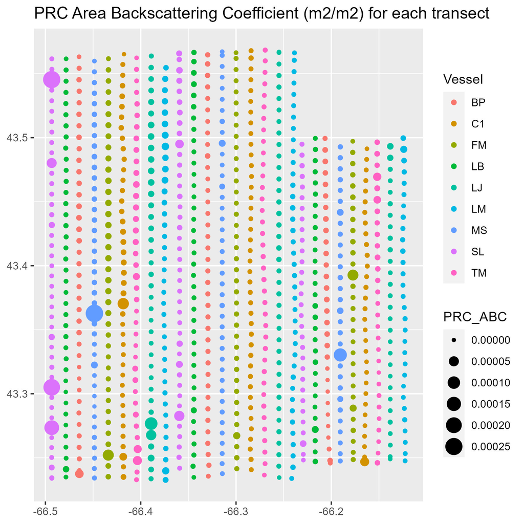

### Transect Details

Table 1: Transect Details

| Vessel | Transect # | Date/Time Start | Date/Time End | Start Lon | Start Lat | End Lon | End Lat | Location | Distance (km) | Speed |
| --- | --- | --- | --- | --- | --- | --- | --- | --- | --- | --- |
| BP | T01 | 2023-09-04 01:18:30 | 2023-09-04 03:38:23 | -66.463 | 43.566 | -66.464 | 43.237 | GB | 36.62 | 8.48 |
| BP | T02 | 2023-09-04 04:21:08 | 2023-09-04 06:43:39 | -66.329 | 43.232 | -66.330 | 43.565 | GB | 37.19 | 8.45 |
| BP | T03 | 2023-09-04 07:32:51 | 2023-09-04 09:09:38 | -66.207 | 43.503 | -66.201 | 43.246 | GB | 28.64 | 9.59 |
| C1 | T01 | 2023-09-04 00:30:40 | 2023-09-04 02:47:19 | -66.417 | 43.566 | -66.418 | 43.234 | GB | 41.13 | 9.75 |
| C1 | T02 | 2023-09-04 03:26:03 | 2023-09-04 05:41:52 | -66.285 | 43.235 | -66.284 | 43.568 | GB | 40.42 | 9.64 |
| C1 | T03 | 2023-09-04 06:30:30 | 2023-09-04 08:11:01 | -66.163 | 43.493 | -66.165 | 43.247 | GB | 29.65 | 9.56 |
| FM | T01 | 2023-09-04 01:25:06 | 2023-09-04 03:43:06 | -66.434 | 43.564 | -66.434 | 43.235 | GB | 38.27 | 8.98 |
| FM | T02 | 2023-09-04 04:24:11 | 2023-09-04 06:39:12 | -66.299 | 43.235 | -66.300 | 43.566 | GB | 38.21 | 9.17 |
| FM | T03 | 2023-09-04 07:27:05 | 2023-09-04 09:16:20 | -66.177 | 43.500 | -66.177 | 43.249 | GB | 28.94 | 8.58 |
| LB | T01 | 2023-09-04 00:15:08 | 2023-09-04 02:42:20 | -66.478 | 43.566 | -66.478 | 43.235 | GB | 38.30 | 8.43 |
| LB | T02 | 2023-09-04 03:31:17 | 2023-09-04 05:41:00 | -66.344 | 43.234 | -66.344 | 43.567 | GB | 37.91 | 9.47 |
| LB | T03 | 2023-09-04 06:36:34 | 2023-09-04 08:24:29 | -66.217 | 43.501 | -66.217 | 43.247 | GB | 29.07 | 8.73 |
| LJ | T01 | 2023-09-04 00:22:50 | 2023-09-04 02:44:56 | -66.389 | 43.566 | -66.389 | 43.234 | GB | 37.03 | 8.44 |
| LJ | T02 | 2023-09-04 03:26:03 | 2023-09-04 05:43:21 | -66.255 | 43.234 | -66.255 | 43.567 | GB | 37.14 | 8.76 |
| LJ | T03 | 2023-09-04 06:29:07 | 2023-09-04 08:14:49 | -66.138 | 43.501 | -66.138 | 43.249 | GB | 28.04 | 8.60 |
| LM | T01 | 2023-09-04 00:17:16 | 2023-09-04 02:41:40 | -66.373 | 43.560 | -66.374 | 43.233 | GB | 37.48 | 8.41 |
| LM | T02 | 2023-09-04 03:20:47 | 2023-09-04 05:33:48 | -66.242 | 43.230 | -66.239 | 43.566 | GB | 38.04 | 9.27 |
| LM | T03 | 2023-09-04 06:15:54 | 2023-09-04 08:04:45 | -66.125 | 43.502 | -66.123 | 43.248 | GB | 28.88 | 8.60 |
| MS | T01 | 2023-09-04 00:24:48 | 2023-09-04 02:42:59 | -66.449 | 43.565 | -66.449 | 43.234 | GB | 40.54 | 9.50 |
| MS | T02 | 2023-09-04 03:29:51 | 2023-09-04 05:48:20 | -66.314 | 43.234 | -66.314 | 43.567 | GB | 39.77 | 9.30 |
| MS | T03 | 2023-09-04 06:45:15 | 2023-09-04 08:32:31 | -66.190 | 43.501 | -66.191 | 43.247 | GB | 29.61 | 8.94 |
| SL | T01 | 2023-09-04 01:20:59 | 2023-09-04 03:49:10 | -66.493 | 43.569 | -66.493 | 43.234 | GB | 41.98 | 9.18 |
| SL | T02 | 2023-09-04 04:28:57 | 2023-09-04 06:42:25 | -66.361 | 43.237 | -66.360 | 43.566 | GB | 40.12 | 9.74 |
| SL | T03 | 2023-09-04 07:30:29 | 2023-09-04 09:15:30 | -66.230 | 43.501 | -66.229 | 43.248 | GB | 30.26 | 9.33 |
| TM | T01 | 2023-09-04 00:22:32 | 2023-09-04 02:48:21 | -66.405 | 43.566 | -66.404 | 43.233 | GB | 37.10 | 8.24 |
| TM | T02 | 2023-09-04 03:32:09 | 2023-09-04 05:43:06 | -66.271 | 43.234 | -66.269 | 43.568 | GB | 37.20 | 9.20 |
| TM | T03 | 2023-09-04 06:30:24 | 2023-09-04 08:14:47 | -66.152 | 43.504 | -66.152 | 43.246 | GB | 28.69 | 8.91 |

### Survey Summary

Table 2: Acoustic Survey Results

| Vessel | Transect No. | Target Strength (db/kg) | Mean Sa (/m2) | Biomass Density (kg/m2) |
| --- | --- | --- | --- | --- |
| SL | T01 | -35.5 | -47.661 | 0.061 |
| MS | T01 | -35.5 | -51.129 | 0.027 |
| LJ | T01 | -35.5 | -51.331 | 0.026 |
| FM | T01 | -35.5 | -52.778 | 0.019 |
| MS | T03 | -35.5 | -52.787 | 0.019 |
| TM | T01 | -35.5 | -54.101 | 0.014 |
| C1 | T01 | -35.5 | -54.177 | 0.014 |
| SL | T02 | -35.5 | -54.378 | 0.013 |
| FM | T03 | -35.5 | -54.448 | 0.013 |
| LM | T01 | -35.5 | -54.801 | 0.012 |
| TM | T03 | -35.5 | -55.965 | 0.009 |
| BP | T01 | -35.5 | -57.083 | 0.007 |
| C1 | T03 | -35.5 | -57.462 | 0.006 |
| BP | T03 | -35.5 | -57.800 | 0.006 |
| LM | T03 | -35.5 | -58.814 | 0.005 |
| LB | T03 | -35.5 | -59.015 | 0.004 |
| FM | T02 | -35.5 | -59.482 | 0.004 |
| LM | T02 | -35.5 | -60.120 | 0.003 |
| LJ | T03 | -35.5 | -60.180 | 0.003 |
| BP | T02 | -35.5 | -60.213 | 0.003 |
| LB | T02 | -35.5 | -60.273 | 0.003 |
| LJ | T02 | -35.5 | -60.461 | 0.003 |
| SL | T03 | -35.5 | -60.828 | 0.003 |
| MS | T02 | -35.5 | -60.882 | 0.003 |
| LB | T01 | -35.5 | -61.003 | 0.003 |
| TM | T02 | -35.5 | -61.751 | 0.002 |
| C1 | T02 | -35.5 | -61.798 | 0.002 |

Note:  
Transects are listed from greatest to least backscatter.

Table 3: Survey Summary Table

| Layer | Target Strength | Area (km2) | Mean Sa | Density (kg/m2) | Biomass (tons) | Percent Area | Percent Biomass | Standard Error (tons) | Standard Error (%) |
| --- | --- | --- | --- | --- | --- | --- | --- | --- | --- |
| German Bank | -35.5 | 796 | -54.5268 | 0.0122 | 9,959.441 | NA | NA | 2,734.10 | 27.45 |
| Seal Island | -35.5 | 272 | -56.7016 | 0.0076 | 2,062.584 | NA | NA | 468.31 | 22.70 |
| School Survey | NA | NA | NA | NA | NA | NA | NA | NA | NA |

### Greatest Biomass Densities

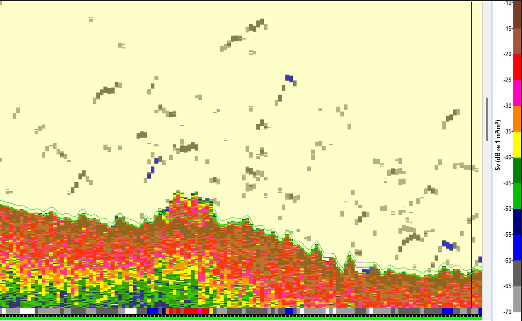

A snip from the transect with the greatest biomass density (kg/m2)

The single point with the largest biomass density (kg/m2) was recorded by **MS**, at the following location:

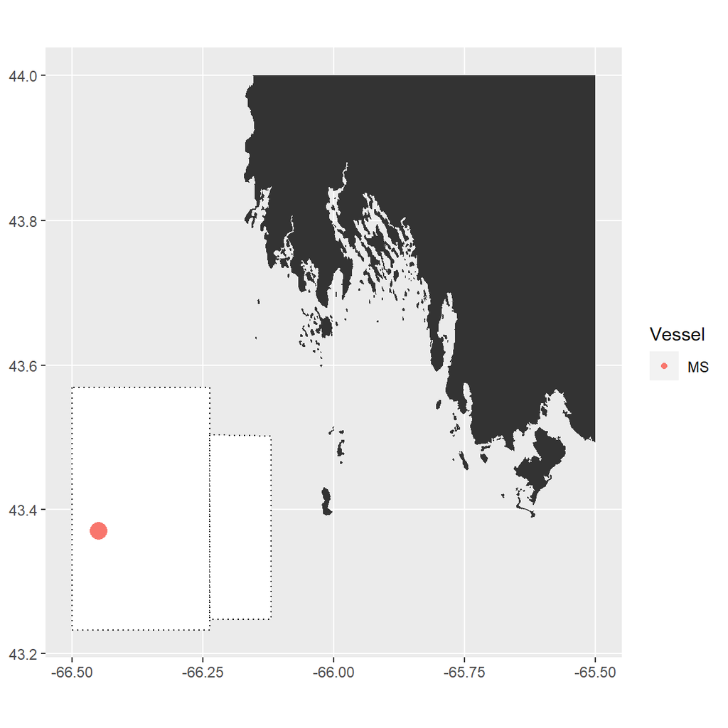

The transect with the greatest average biomass density (kg/m2) was recorded by **SL**, at the following location:

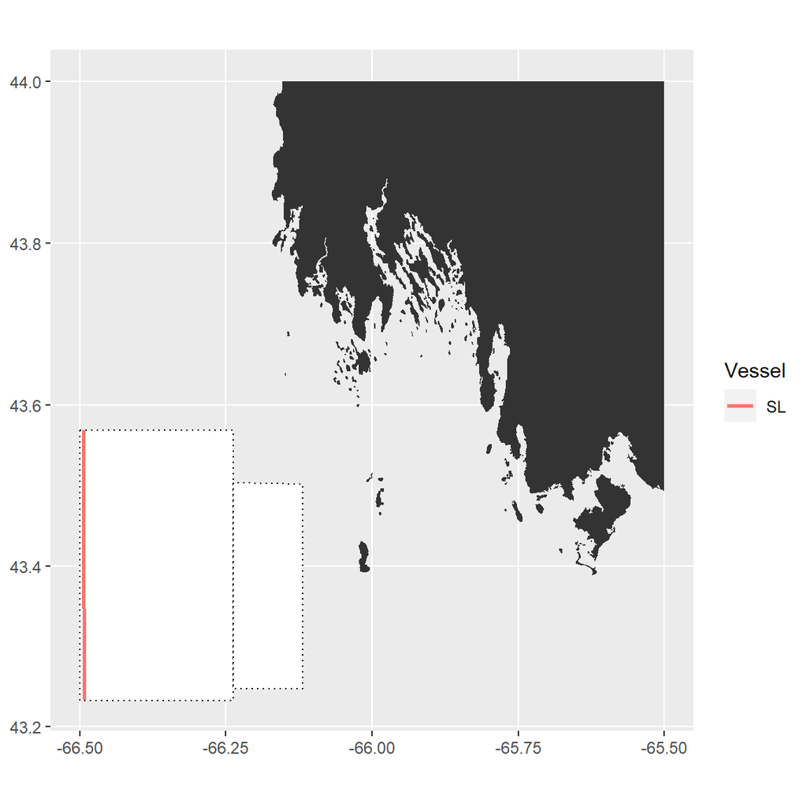

### Annual Summaries

Table 4: Annual Comparison Table

| Ground | Survey Number | Current Year Survey Date | Current Year HSC Estimate | Current Year HSC Turnover Adjusted | Previous Year Survey Date | Previous Year HSC Estimate | Previous Year HSC Turnover Adjusted | Previous Year DFO Estimate | Previous Year DFO Turnover Adjusted |
| --- | --- | --- | --- | --- | --- | --- | --- | --- | --- |
| German Bank | 1 | 2023-08-06 | 2,686.514 | NA | 2022-08-14 | 16,285 | 16,285 | 22,081 | 22,081 |
| Seal Island | 1 | 2023-08-06 | 1,205.361 | NA | 2022-08-14 | 2,598 | 2,598 | 2,086 | 2,086 |
| German Bank | 2 | 2023-08-20 | 4,930.454 | 4,406.486 | 2022-08-28 | 7,472 | 4,296 | 11,699 | 7,393 |
| Seal Island | 2 | 2023-08-20 | 1,917.847 | NA | 2022-08-28 | 1,048 | 1,048 | 570 | 570 |
| German Bank | 3 | 2023-09-03 | 9,959.441 | 8,901.000 | 2022-09-11 | 12,507 | 10,464 | 11,902 | 8,826 |
| Seal Island | 3 | 2023-09-03 | 2,062.584 | NA | 2022-09-11 | 6,941 | 6,941 | 6,392 | 6,392 |
| German Bank | 4 | NA | NA | NA | 2022-09-25 | 15,924 | 13,216 | 12,503 | 9,761 |
| German Bank | 5 | NA | NA | NA | 2022-10-10 | 19,539 | 16,337 | 20,247 | 17,675 |
| German Bank | 6 | NA | NA | NA | 2022-10-23 | 13,399 | 8,684 | 15,565 | 10,823 |
| Seal Island | 4 | NA | NA | NA | 2022-09-25 | 4,634 | 4,634 | 3,732 | 3,732 |
| Seal Island | 5 | NA | NA | NA | 2022-10-10 | 5,243 | 5,243 | 5,604 | 5,604 |
| Seal Island | 6 | NA | NA | NA | 2022-10-23 | 2,944 | 2,944 | 3,260 | 3,260 |

Table 5: Annual Summary Table

| Year | Ground | HSC Estimate | HSC Turnover Adjusted | DFO Estimate | DFO Turnover Adjusted |
| --- | --- | --- | --- | --- | --- |
| 2022 | German Bank | 85,126.000 | 69,282 | 93,997 | 76,559 |
| 2022 | Seal Island | 23,408.000 | 23,408 | 21,644 | 21,644 |
| 2023 | German Bank | 17,576.410 | NA | NA | NA |
| 2023 | Seal Island | 5,185.792 | NA | NA | NA |

## Tagging, Plankton, and CTD Data

### Tag Data

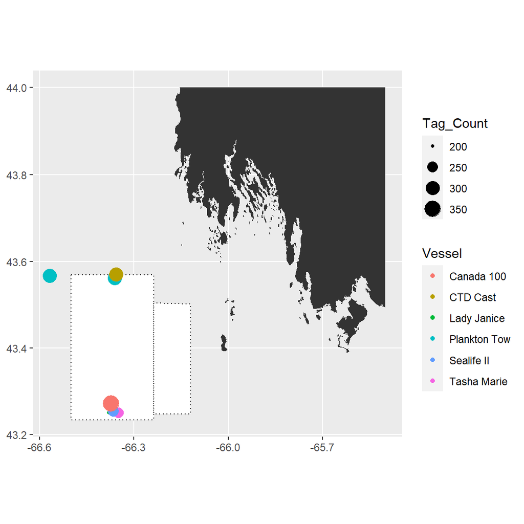

[output not shown]

### Plankton Data

#### Tow Summary Table

|  | Tow 1 | Tow 2 |
| --- | --- | --- |
| **Base Details** |  |  |
| Vessel | Lady Melissa | Lady Melissa |
| Set Number | GB2023-05 | GB2023-06 |
| Ground | GB | GB |
| Date | 03/09/2023 | 03/09/2023 |
| Wind Direction (km/h) | SE | SE |
| Swell (m) | 0.5 | 0.5 |
| Air Temp (c) | 16 | 16 |
| **Tow Details** |  |  |
| Tow Start | 19:17:00 | 19:35:00 |
| Tow End | 19:27:00 | 19:45:00 |
| Start Lat | 43.56667 | 43.56167 |
| End Lat | 43.55333 | 43.57333 |
| Start Lon | -66.56833 | -66.36167 |
| End Lon | -66.35167 | -66.35833 |
| Avg Tow Depth (m) | 7.282253 | 6.310865 |
| Speed | 5.6 | 5.4 |
| Heading | 180 | 0 |
| Tide Direction | with | against |
| **Other Data Collection** |  |  |
| Flow Start | 965677 | 11733 |
| Flow End | 11733 | 78413 |
| No. Revolutions | -953944 | 66680 |
| Distance (m) | -25635.337 | 1791.892 |
| Volume | -80533.412 | 5629.228 |
| Secchi Disappear (m) | 7 | 7 |
| Secchi Reappear (m) | 6 | 6 |

#### Tow Depth Profiles

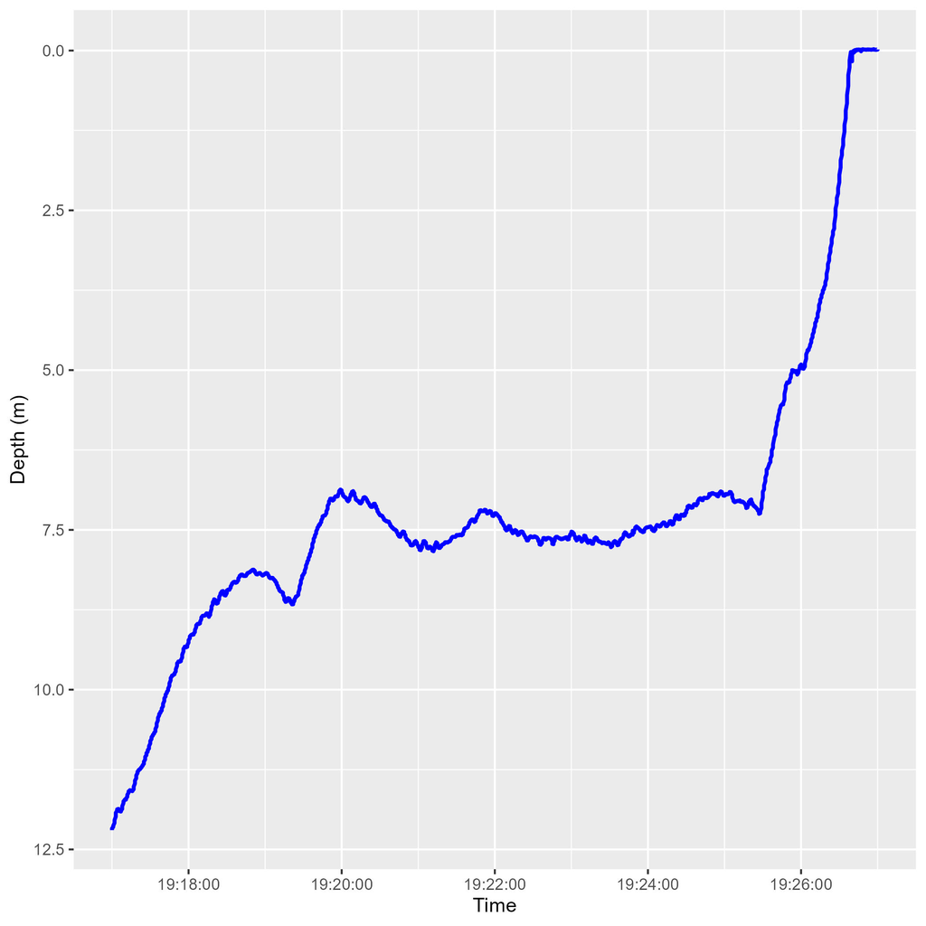

Plankton tow depth profile #1

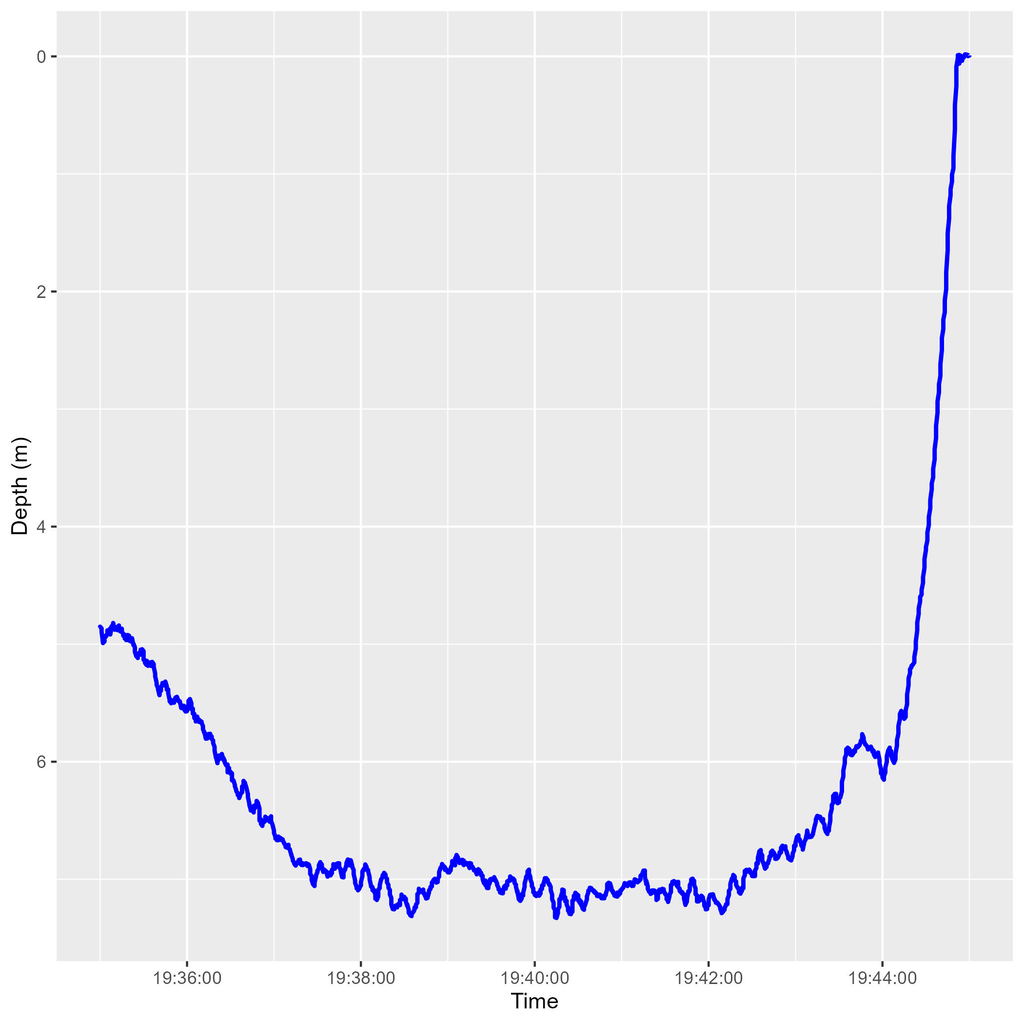

Plankton tow depth profile #2

The first tow is GB2023-05, which was with the tide and had an average depth of 7.2822531m. The second tow is GB2023-06, which was against the tide and had an average depth of 6.3108651m.

#### Captured plankton

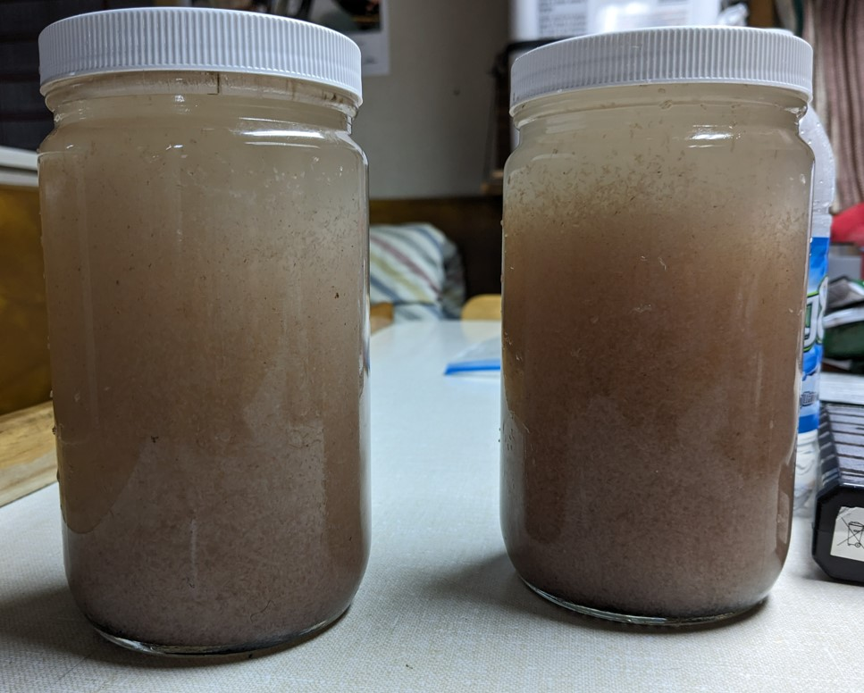

Captured plankton from the surface tows

### CTD Data

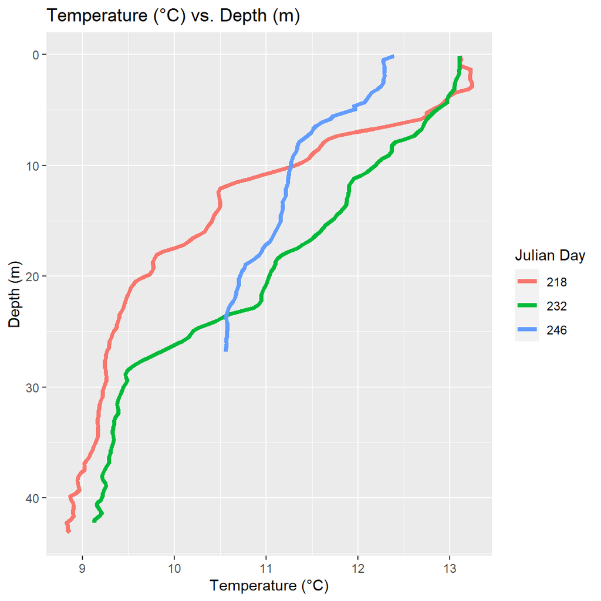

CTD depth profiles for all 2023 German Bank surveys so far.

#### Sea surface temperatures

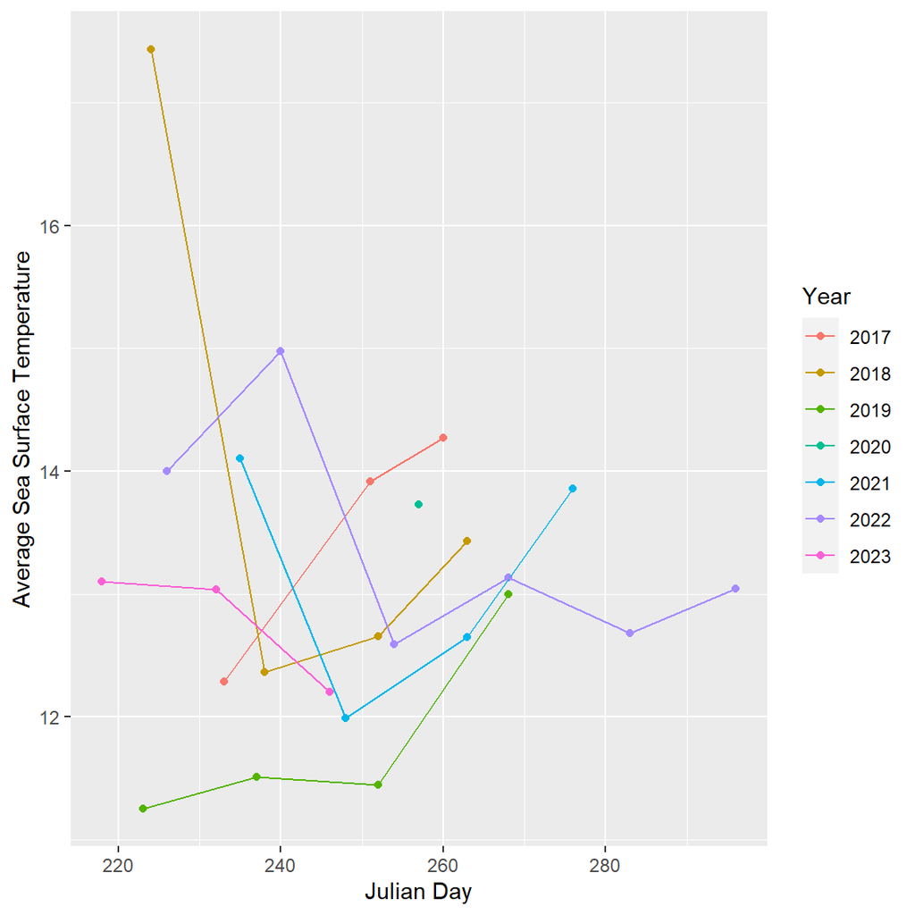

Annual average sea surface temperatures (SST) for German Bank.

## Vessel Performance

### Speed

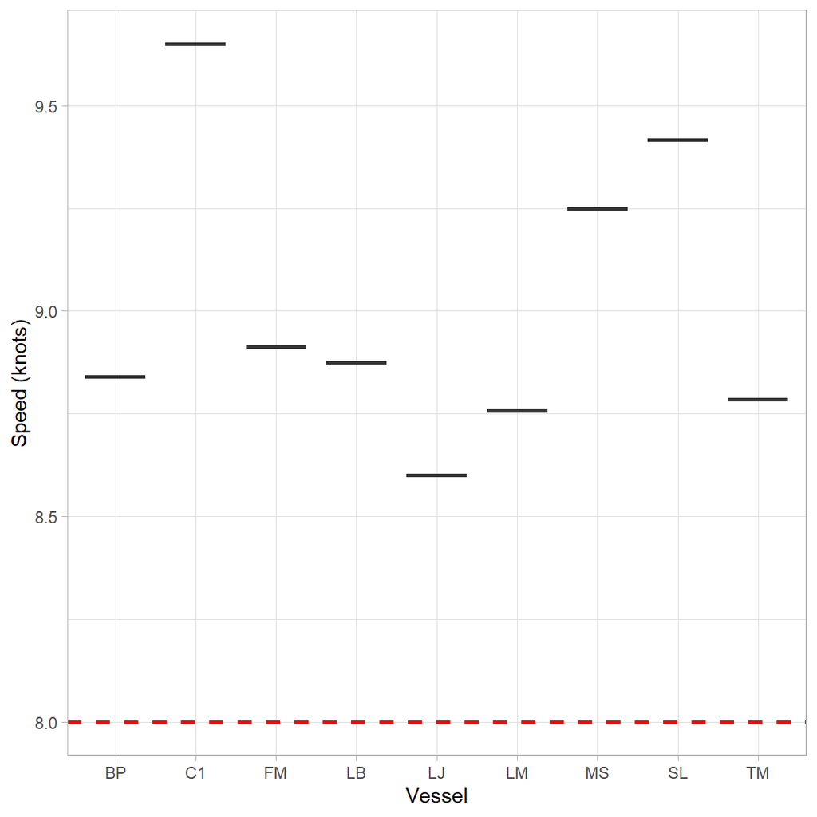

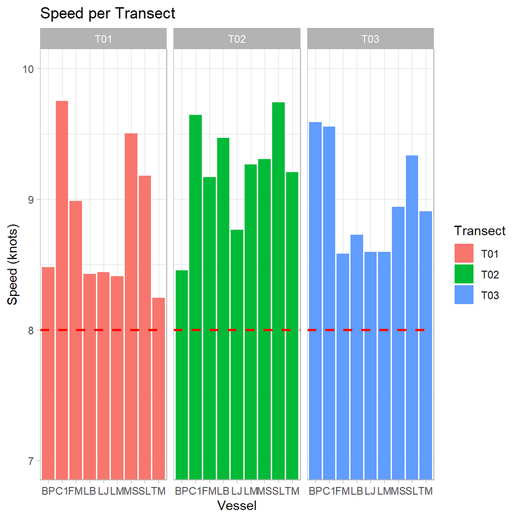

Average vessel speed was 9.01. This is above the 8 knot requirement; vessels are urged to slow down to prevent backscatter noise from interfering with the acoustic data.

### Distance

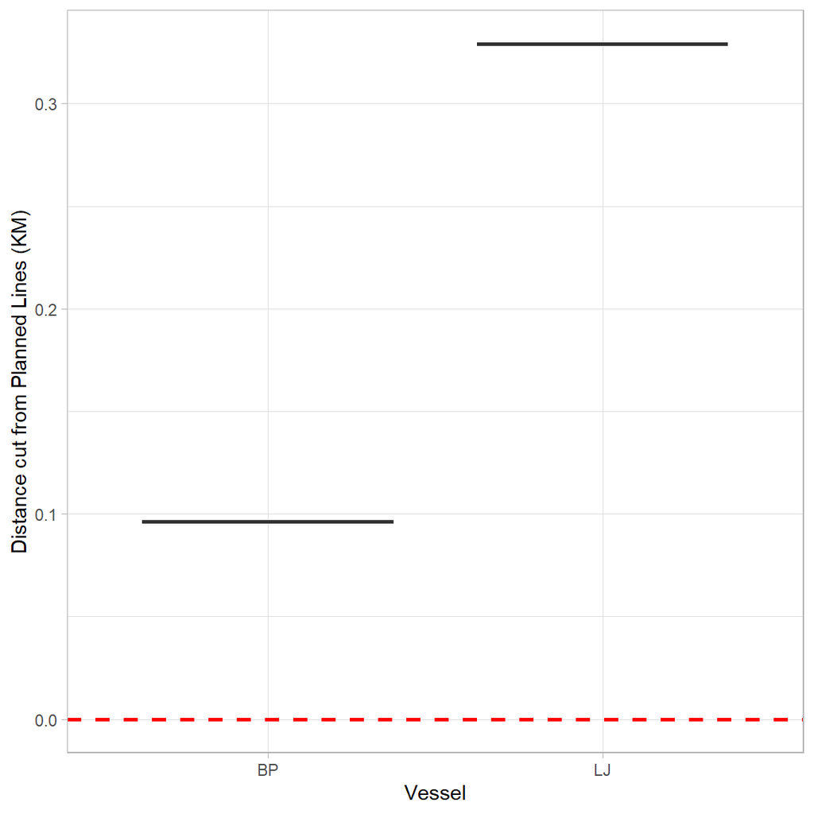

No significant distance was cut from the planned lines; vessels covered the planned area well.